# Sepsis AI Model by Radoslav Radev (iteration 2.1)

A separate notebook (iteration2.5) is available where i combine an aditional dataset

#### changlog iteration 2

after recent feedback I:

- changed the scaling range to (0,1).
- balanced the dataset 50/50 positive and negative cases
- put more emphasis on data understanding
- played with different hyperparams
- went more in depth of the evaluation section of the notebook

#### changlog iteration 2.1

after recent feedback I:

- dove deeper into the limitations of my dataset
- investigated the effects of balancing my dataset and added more reasoning to my decision

#### changlog iteration 2.5

- a new notebook was added where i combine an additional dataset

#### changlog iteration 3

after recent feedback I:

- updated my reasoning in the evaluation and went more in depth
- compared the performance of the 3 datasets and chose the combined one (please see the addition notebook)

#### changlog iteration 3.1

after recent feedback I: added a section showcasing tunning of hyper-parameters

### Introduction

This project aims to develop a model that can predict sepsis. Sepsis is a life-threatening condition caused by the body's response to an infection. Early recognition and timely intervention are essential to improve patient outcomes.

# Data Requirements for Sepsis Detection Model:

We will require a sizable and varied dataset of patients with both sepsis and non-sepsis cases in order to develop an accurate and efficient AI model for sepsis detection.patient demographics, vital signs, test results, and other pertinent clinical data should be included in the dataset.

Specifically, our dataset should contain the following data elements:

1. Patient demographics: ex.: (age)
2. Vital signs: ex.: (blood pressure)
3. Laboratory results: ex.: (blood work)

Also, it's crucial to make sure that our dataset includes people with a variety of ages, genders, races, and medical histories to accurately predict sepsis in a broad range of demographics

We can train our AI model to correctly identify sepsis in patients by collecting and evaluating this data, which will improve patient outcomes and maybe save lives.

## Data Collection:

The dataset i will be using for this individual challenge is provided by Johns Hopkins University, which is a private research university in Baltimore, Maryland U.S

the data set is relatively small and contains only 600 records with the fiollowing data:

| Column Name | Attribute/Target | Description |
| --- | --- | --- |
| ID | N/A | Unique number to represent patient ID |
| PRG | Attribute1 | Plasma glucose |
| PL | Attribute 2 | Blood Work Result-1 (mu U/ml) |
| PR | Attribute 3 | Blood Pressure (mm Hg) |
| SK | Attribute 4 | Blood Work Result-2 (mm) |
| TS | Attribute 5 | Blood Work Result-3 (mu U/ml) |
| M11 | Attribute 6 | Body mass index (weight in kg/(height in m)^2 |
| BD2 | Attribute 7 | Blood Work Result-4 (mu U/ml) |
| Age | Attribute 8 | patients age (years) |
| Insurance | N/A | If a patient holds a valid insurance card |
| Sepssis | Target | Positive: if a patient in ICU will develop a sepsis , and Negative: otherwise |

## Data Reliability

We need to ask ourselves where is the data coming from , who it represents and how it was collected, is it diverse enough, is it relevent

- the data is coming from Baltimore, Maryland U.S
  - this might not be representative for individuals from europe
- unfortunately we don't know if it`s coming from a single hospital (if it is, Is a private hospital? - this could reflect weightier individuals) , after all these are concerns that will make our model less generalized
- as we would love a larger dataset representative of diverse races, and medical histories, this dataset will satisfy our purposes

While it would be ideal to have a diverse and representative dataset, the limitations of the dataset provided by Johns Hopkins University may not have a significant impact on our results. The dataset may still provide valuable insights and help us understand the trends and patterns of sepsis in the population.

It is important to keep in mind that no dataset is perfect and there will always be some limitations and biases that need to be taken into account.

Moreover, Johns Hopkins University is a reputable research institution with a strong track record in healthcare research, which gives us confidence in the quality and reliability of the dataset.

Overall, while it is important to be aware of the limitations of the dataset, we should not overemphasize its shortcomings or dismiss its value altogether. With careful analysis and interpretation, the dataset can still provide valuable insights and inform healthcare decision making.

```python
import sklearn
import pandas
import seaborn
import numpy as np

from sklearn.preprocessing import StandardScaler
from sklearn import preprocessing
from sklearn.svm import SVC
from sklearn.metrics import accuracy_score, confusion_matrix
```

## Data Provisioning

```python
columns = ["ID", "PRG", "PL", "PR", "SK", "TS", "M11", "BD2", "Age","Insurance", "Sepssis"]
df = pandas.read_csv("Paitients_Files_Train.csv" , names=columns)
df.sample(10)
```

|  | ID | PRG | PL | PR | SK | TS | M11 | BD2 | Age | Insurance | Sepssis |
| --- | --- | --- | --- | --- | --- | --- | --- | --- | --- | --- | --- |
| 36 | ICU200046 | 11 | 138 | 76 | 0 | 0 | 33.2 | 0.420 | 35 | 0 | Negative |
| 96 | ICU200106 | 2 | 92 | 62 | 28 | 0 | 31.6 | 0.130 | 24 | 1 | Negative |
| 486 | ICU200496 | 1 | 139 | 62 | 41 | 480 | 40.7 | 0.536 | 21 | 1 | Negative |
| 27 | ICU200037 | 1 | 97 | 66 | 15 | 140 | 23.2 | 0.487 | 22 | 1 | Negative |
| 283 | ICU200293 | 7 | 161 | 86 | 0 | 0 | 30.4 | 0.165 | 47 | 0 | Positive |
| 444 | ICU200454 | 4 | 117 | 62 | 12 | 0 | 29.7 | 0.380 | 30 | 1 | Positive |
| 392 | ICU200402 | 1 | 131 | 64 | 14 | 415 | 23.7 | 0.389 | 21 | 0 | Negative |
| 173 | ICU200183 | 1 | 79 | 60 | 42 | 48 | 43.5 | 0.678 | 23 | 1 | Negative |
| 355 | ICU200365 | 9 | 165 | 88 | 0 | 0 | 30.4 | 0.302 | 49 | 1 | Positive |
| 119 | ICU200129 | 4 | 99 | 76 | 15 | 51 | 23.2 | 0.223 | 21 | 1 | Negative |

```python
group_info = df.groupby(["Sepssis"])["Sepssis"].count()
group_info
```

```
Sepssis
Negative    391
Positive    208
Name: Sepssis, dtype: int64
```

## balancing the dataset

i preformed the following SQL over our source dataset to even out the positive and negative cases

```
DELETE FROM "Paitients_Files_Train"  WHERE ID IN (
    SELECT ID FROM "Paitients_Files_Train"  WHERE Sepssis = 'Negative' ORDER BY RANDOM() LIMIT 183
  )
```

```python
df = pandas.read_csv("Balanced_Paitients_Files_Train.csv" , names=columns)
group_info = df.groupby(["Sepssis"])["Sepssis"].count()
group_info
```

```
Sepssis
Negative    208
Positive    208
Name: Sepssis, dtype: int64
```

this clearly improved our positive cases accuracy but i am asking my self if this way we are not overfitting the model

it is important to think about the real world use of our model and if 50/50 split of the cases represents it: in the open world the ratio of positive to negative cases is really large but in the targeted use case of our model (patients that are at high risk of sepsis and/or we have suspicion of) the gap is significantly smaller so balancing the dataset is the right choice

## Data Understanding

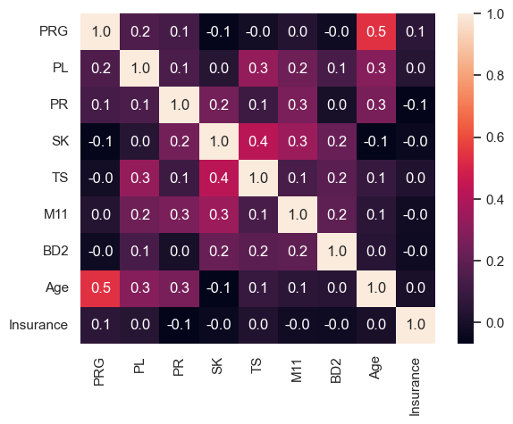

```python
import matplotlib.pyplot as plt
corr = df.corr(numeric_only=True)
plot = seaborn.heatmap(corr, cbar=True, annot=True, fmt=".1f")
```

- with the age the plasma glucose in blood increases
- there is also a corelation between BloodWork-Result-2 and BloodWork-Result-3 witch is not surprising

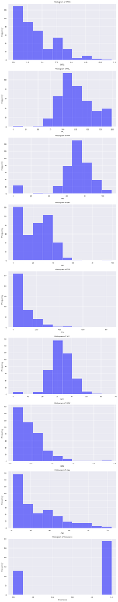

```python
import matplotlib.pyplot as plt
fig, axs = plt.subplots(nrows=len(columns[1:-1]), ncols=1, figsize=(10, 50))

for i, column in enumerate(columns[1:-1]):
    axs[i].hist(df[column], bins=10, alpha=0.5, color='blue')
    axs[i].set_xlabel(column)
    axs[i].set_ylabel('Frequency')
    axs[i].set_title(f'Histogram of {column}')

# Adjust the spacing between subplots
plt.tight_layout()
plt.show()
```

### Data Preparation (scaling -> feature selection -> removing outliers)

after getting a general understand of how does the data looks like, I have determent that we need to scale the data and remove the ID column as it is not relevant for us, after a quick google dork i didn`t find the ID present in other datasets

```python
from sklearn.preprocessing import StandardScaler, MinMaxScaler

df.drop(columns=["ID"], inplace=True)
from sklearn import preprocessing
encoder = preprocessing.LabelEncoder()
df["Sepssis"] = encoder.fit_transform(df["Sepssis"])

# Separate the target variable from the input features
X = df.iloc[:,:-1]  # input features
y = df.iloc[:, -1]  # target variable (sepsis)

# Scale the input features only\
#scaler = StandardScaler()
scaler = MinMaxScaler(feature_range=(0, 1))
scaler.fit(X)
X_scaled = scaler.transform(X)

# Combine the scaled input features and the target variable
df_scaled = pandas.concat([pandas.DataFrame(X_scaled, columns=X.columns), y], axis=1)
df_scaled.head()
```

|  | PRG | PL | PR | SK | TS | M11 | BD2 | Age | Insurance | Sepssis |
| --- | --- | --- | --- | --- | --- | --- | --- | --- | --- | --- |
| 0 | 0.352941 | 0.747475 | 0.654545 | 0.353535 | 0.000000 | 0.500745 | 0.234415 | 0.568627 | 0.0 | 1 |
| 1 | 0.058824 | 0.429293 | 0.600000 | 0.292929 | 0.000000 | 0.396423 | 0.116567 | 0.196078 | 0.0 | 0 |
| 2 | 0.470588 | 0.924242 | 0.581818 | 0.000000 | 0.000000 | 0.347243 | 0.253629 | 0.215686 | 1.0 | 1 |
| 3 | 0.058824 | 0.449495 | 0.600000 | 0.232323 | 0.111111 | 0.418778 | 0.038002 | 0.000000 | 1.0 | 0 |
| 4 | 0.000000 | 0.691919 | 0.363636 | 0.353535 | 0.198582 | 0.642325 | 0.943638 | 0.235294 | 1.0 | 1 |

## Feature Selection

after scaling the data it`s time to draw a couple of boxplots to the determine the most relevant features for our model

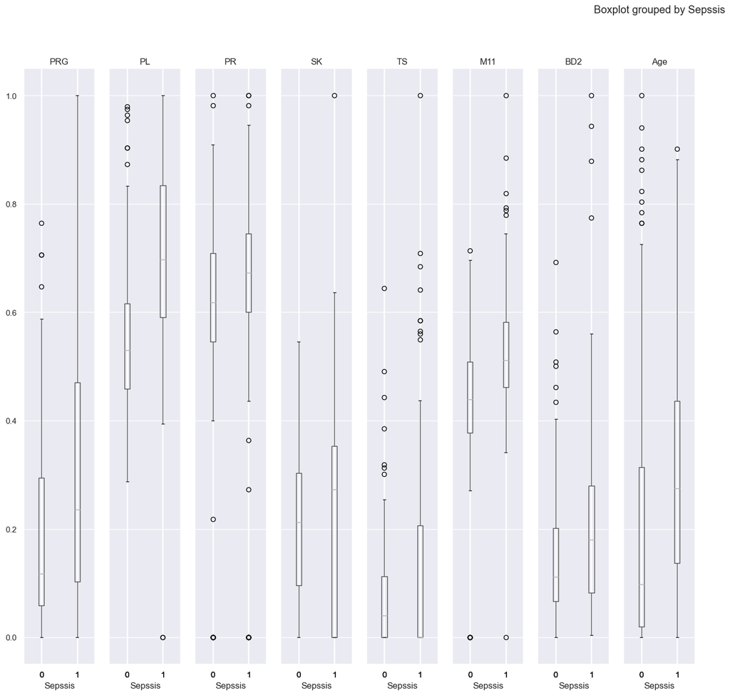

```python
candidates = columns[1:-2]

plot = df_scaled.boxplot(column=candidates, by="Sepssis", figsize=(30,15), layout=(1,15))
```

## Removing Outliers

i played with the threshold value and if i remove more edge cases from the data i actually remove most of the positive cases and ofcourse the acuracy for predicting a positives drops really low so i made a safe definition between edge cases and outliers and decided to set the treshold to 5

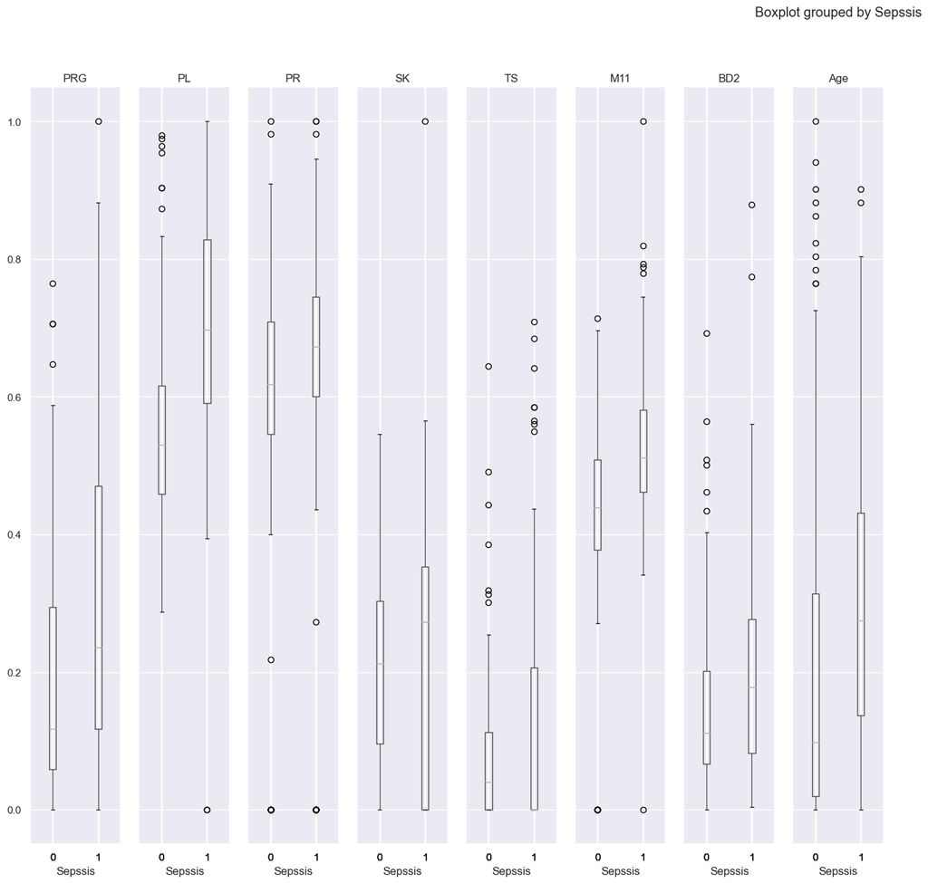

```python
z_scores = np.abs((df[candidates] - df[candidates].mean()) / df[candidates].std())
threshold = 5
df_cleaned = df_scaled[(z_scores < threshold).all(axis=1)]
plot = df_cleaned.boxplot(column=candidates, by="Sepssis", figsize=(30, 15), layout=(1, 15))
```

## Selecting Features and Splitting the Data

after looking at the boxplots i have decided to use the following features for my model: Blood Work Result-1, patients age, Body mass index and Blood Pressure i chose these features because they have the most significant difference between the positive and negative cases in iteration 0, now I added the Blood Work Result-3, since after cleaning the data it looks like a good candidate to increse our positive accuracy a little bit

```python
features = ["PL", "Age", "M11", "PR", "TS"]
target = "Sepssis"
X = df_cleaned[features]
y = df_cleaned[target]


from sklearn.model_selection import train_test_split
X_train, X_test, y_train, y_test = train_test_split(X, y, test_size=0.2)
print("There are in total", len(X), "observations, of which", len(X_train), "are now in the train set, and", len(X_test), "in the test set.")
```

```
There are in total 413 observations, of which 330 are now in the train set, and 83 in the test set.
```

#### Lets look at a couple of scatter plots to help us visualize the relationship between our selected features

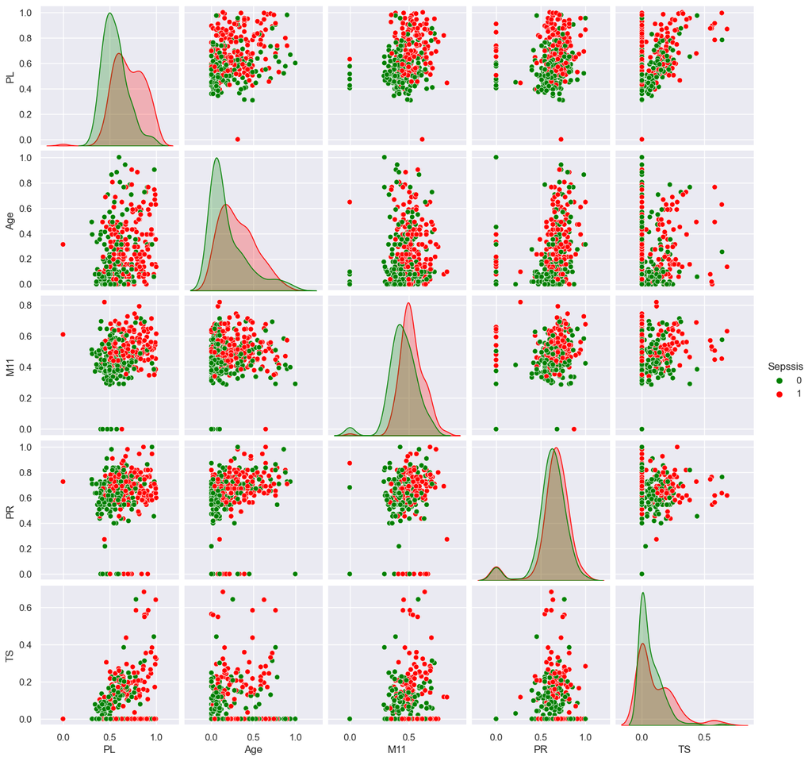

```python
train_df = pandas.concat([X_train, y_train], axis=1)
seaborn.set_theme()
cmap = {1: "red", 0: "green"}
seaborn.pairplot(train_df, hue=target, palette=cmap )
```

it is hard to see any patterns or coloration between the features

## Modeling

i decided on switching the NearestNeighbor algorithm for a LogisticRegression algorithm (the difference between it and RandomForest was vary insignificant but the LogisticRegression was more consistent with the results)

for more detailed information about the model choosing phase please take a look at the modelSelection notebook

```python
from sklearn.linear_model import LogisticRegression
from sklearn.metrics import accuracy_score, classification_report
from sklearn.model_selection import cross_val_score

target_names = [encoder.classes_[0], encoder.classes_[1]]
# Train and evaluate model with Logistic Regression
clf = LogisticRegression(C=1, class_weight=None, penalty='l2', max_iter=100,solver='lbfgs')
clf.fit(X_train, y_train)
y_pred = clf.predict(X_test)
acc = accuracy_score(y_test, y_pred)
print("Accuracy:", acc)
print(classification_report(y_test, y_pred, target_names=target_names))
print("Cross validation results",cross_val_score(clf, X, y, cv=5))
```

```
Accuracy: 0.7951807228915663
              precision    recall  f1-score   support

    Negative       0.74      0.90      0.81        41
    Positive       0.88      0.69      0.77        42

    accuracy                           0.80        83
   macro avg       0.81      0.80      0.79        83
weighted avg       0.81      0.80      0.79        83

Cross validation results [0.74698795 0.71084337 0.69879518 0.75609756 0.76829268]
```

## Evaluation

#### iteration1

iteration1 showed an improvement in performance over iteration 0, with an accuracy of above 75%. The precision and recall of negative cases indicating that the algorithm had a good ability to identify them. The precision and recall for positive cases has been incresed by arround 20% from iteration 0 , the algorithm can still benefit from improvement in identifying positive cases.

#### iteration2

- after playing with the hyperparameters of LogisiticRegresion() explicited in the code cell above and explained in the MD cell bellow I have determent that they don't have any significant effect on the accuracy of the model and left them on default.

However, balancing the dataset did have a significant effect on the accuracy of the model.

- in our case both Recall (the proportion of true positives that were correctly identified by the model among all actual positive instances.) and Precision (the proportion of true positives (correctly classified positive instances) among all instances predicted as positive by the model) are important , and i am pretty happy with the results i managed to produce from this dataset

#### final evaluation of the first dataset

The macro-average and weighted-average f1-scores are also the same, indicating that the model is performing equally well for both classes.

## hyperparamethers

- C: controls the regularization strength. Reducing the value can prevent overfitting but may also result in underfitting and vice versa. Not applicable in our case since our model is neither overfitted or underfitted
- class_weight parameter can be used to balance the weight of each class

This is useful when the classes are imbalanced, and we want to ensure that the model pays more attention to the minority class. In our case it`s not applicable since we have an equal amount of samples for each feature.

- penalty

- max_iter controls the maximum number of iterations for convergence, we can increase this value if the model is not converging (reaching the optimal solution path) within the current number of iterations. This may occur if the dataset is large (it is not aplicable in our use case)
- solver selects the optimization algorithm used. different solvers may yield different results (which i didnt conclude when trying them out for our model)

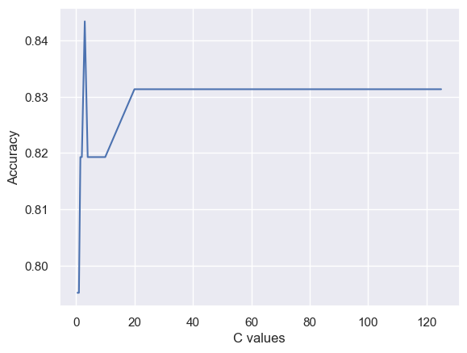

```python
from sklearn.linear_model import LogisticRegression
from sklearn.metrics import accuracy_score
import matplotlib.pyplot as plt
C_values = [0.5,1,1.5,2,2.5,3,3.5,4,4.5, 5, 10, 20,21,22,23,24,25,26,27,28,29,30,31,32,33,34,35,36,37,38,39,40,41,42,43,44,45,46,47,48,49,50, 100, 125]
accResults = []

for C in C_values:
    # Train the model
    clf = LogisticRegression(C=C, class_weight=None, penalty='l2', max_iter=100, solver='lbfgs')
    clf.fit(X_train, y_train)

    # Evaluate the model
    y_pred = clf.predict(X_test)
    acc = accuracy_score(y_test, y_pred)
    accResults.append(acc)

# Plot the accuracy values for each C value
plt.plot(C_values, accResults)
plt.xlabel('C values')
plt.ylabel('Accuracy')
plt.show()
```

##### lets zoom in on the spike of 0 to 6

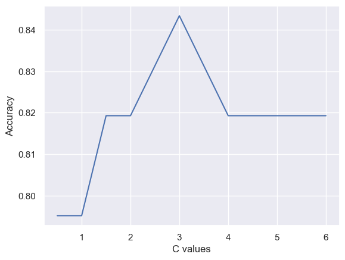

```python
C_values = [0.5,1,1.5,2,2.5, 3,3.5,4,4.5,5,5.5,6]
accResults = []

for C in C_values:
    # Train the model
    clf = LogisticRegression(C=C, class_weight=None, penalty='l2', max_iter=100, solver='lbfgs')
    clf.fit(X_train, y_train)

    # Evaluate the model
    y_pred = clf.predict(X_test)
    acc = accuracy_score(y_test, y_pred)
    accResults.append(acc)

# Plot the accuracy values for each C value
plt.plot(C_values, accResults)
plt.xlabel('C values')
plt.ylabel('Accuracy')
plt.show()
```

##### evaluation of the graphs (FIRST RUN (not reflected in the graphs above since a random seed was not used please read the end of the notebook for explanation and reasoning ))

on this plot we can see the accuracy effect of the C hyperparameter we can see that the highest increase in accuracy occurred between a C value of 1 to 3, with a peak between 2 and 3. Notably, the difference between the highest and lowest values was 2.5%. Additionally, it was observed that after a C value of 100, there was a further increase in accuracy of 1.5%.

lets check what is the best value of C for F1 score

```python
from sklearn.linear_model import LogisticRegression
from sklearn.model_selection import GridSearchCV
from sklearn.metrics import f1_score, recall_score, precision_score, accuracy_score, make_scorer
import matplotlib.pyplot as plt

# Define the parameter grid for the hyperparameters you want to search
param_grid = {'C': [0.5,1,1.5,2,2.5,3,3.5,4,4.5, 5, 10, 20,21,22,23,24,25,26,27,28,29,30,31,32,33,34,35,36,37,38,39,40,41,42,43,44,45,46,47,48,49,50, 100, 200]}

# Create the logistic regression model
clf = LogisticRegression(class_weight=None, penalty='l2', max_iter=100, solver='lbfgs')

# Create the scoring function for F1 score
f1_scorer = make_scorer(f1_score, greater_is_better=True)

# Set up the GridSearchCV
grid_search = GridSearchCV(estimator=clf, param_grid=param_grid, scoring=f1_scorer, cv=5)

# Fit the GridSearchCV to the data
grid_search.fit(X_train, y_train)

# Get the best parameters and the corresponding F1 score
best_params = grid_search.best_params_
best_f1 = grid_search.best_score_

print(f"Best parameters: {best_params}")
print(f"Best F1 score: {best_f1}")

# Evaluate the best model on the test set
best_model = grid_search.best_estimator_
y_pred = best_model.predict(X_test)
test_recall = recall_score(y_test, y_pred)
test_precision = precision_score(y_test, y_pred)
test_accuracy = accuracy_score(y_test, y_pred)
test_f1 = f1_score(y_test, y_pred)

print(f"Test recall: {test_recall}")
print(f"Test precision: {test_precision}")
print(f"Test accuracy: {test_accuracy}")
print(f"Test F1 score: {test_f1}")
```

```
Best parameters: {'C': 35}
Best F1 score: 0.7144337834636343
Test recall: 0.7857142857142857
Test precision: 0.868421052631579
Test accuracy: 0.8313253012048193
Test F1 score: 0.825
```

and now lets check what is the best value of C for recall

```python
param_grid = {'C': [0.5,1,1.5,2,2.5,3,3.5,4,4.5, 5, 10, 20,21,22,23,24,25,26,27,28,29,30,31,32,33,34,35,36,37,38,39,40,41,42,43,44,45,46,47,48,49,50, 100, 200]}

# Create the logistic regression model
clf = LogisticRegression(class_weight=None, penalty='l2', max_iter=100, solver='lbfgs')

# Create the scoring function for recall
recall_scorer = make_scorer(recall_score, greater_is_better=True)

# Set up the GridSearchCV
grid_search = GridSearchCV(estimator=clf, param_grid=param_grid, scoring=recall_scorer, cv=5)

# Fit the GridSearchCV to the data
grid_search.fit(X_train, y_train)

# Get the best parameters and the corresponding recall score
best_params = grid_search.best_params_
best_recall = grid_search.best_score_

print(f"Best parameters: {best_params}")
print(f"Best recall: {best_recall}")

# Evaluate the best model on the test set
best_model = grid_search.best_estimator_
y_pred = best_model.predict(X_test)
test_recall = recall_score(y_test, y_pred)
test_accuracy = accuracy_score(y_test, y_pred)

print(f"Test recall: {test_recall}")
print(f"Test accuracy: {test_accuracy}")
```

```
Best parameters: {'C': 35}
Best recall: 0.7107954545454546
Test recall: 0.7857142857142857
Test accuracy: 0.8313253012048193
```

##### Upon rerunning the notebook

Upon rerunning the notebook, I observed completely different graphs and results compared to the previous run. The main reason for these discrepancies is the absence of a fixed random seed, which introduces a randomness factor in the model's training process. Consequently, the previous conclusion about the optimal value of the C hyperparameter may no longer hold. This finding suggests that tuning for C might be less significant in this scenario due to the influence of randomness.

Although setting a random seed ensures the consistency of results across multiple runs, I have decided not to use it in this case. Fixing a random seed can be detrimental to the generalization of the model, as it may lead to results that are overly reliant on a specific seed value, which may not necessarily reflect the true performance of the model when faced with new data. By allowing randomness in the model training, I aim to build a more robust model that can better adapt to a variety of data.

##### Conclusion

due to the randomness factor and the inconsistent results observed upon rerunning the notebook, tuning for the C hyperparameter in this case appears to be pointless. Even with a fixed random seed, the margins of improvement would be extremely small